博客

发表于 2016-09-05 |

# logistic回归

logistic回归又主要在流行病学中应用较多，比较常用的情形是探索某疾病的危险因素，根据危险因素预测某疾病发生的概率，等等。例如，想探讨胃癌发生的危险因素，可以选择两组人群，一组是胃癌组，一组是非胃癌组，两组人群肯定有不同的体征和生活方式等。这里的因变量就是是否胃癌，即“是”或“否”，为两分类变量，自变量就可以包括很多了，例如年龄、性别、饮食习惯、幽门螺杆菌感染等。自变量既可以是连续的，也可以是分类的。通过logistic回归分析，就可以大致了解到底哪些因素是胃癌的危险因素。

logistic回归的因变量可以是二分类的，也可以是多分类的，但是二分类的更为常用，也更加容易解释。所以实际中最为常用的就是二分类的logistic回归。

在R语言中，进行logistic回归的命令是通过广义线性模型进行的：fm <- glm(formula, family = binomial(link = logit),data=data.frame) ，下面以《统计建模与R软件》中的一个例子来说明用法。

如有50位病人，其中自变量有三项生理指标分别为x1,x2,x3。因变量y是二分变量，表示为生存时间是否在1年以上。数据和代码如下：

### 首先将这四个变量建构一个数据框，取名为life

```r
life = data.frame(
   X1=c(2.5, 173, 119, 10, 502, 4, 14.4, 2, 40, 6.6,21.4, 2.8, 2.5, 6, 3.5, 62.2, 10.8, 21.6, 2, 3.4,5.1, 2.4, 1.7, 1.1, 12.8, 1.2, 3.5, 39.7, 62.4, 2.4,34.7, 28.4, 0.9, 30.6, 5.8, 6.1, 2.7, 4.7, 128, 35,2, 8.5, 2, 2, 4.3, 244.8, 4, 5.1, 32, 1.4),
   X2=rep(c(0, 2, 0, 2, 0, 2, 0, 2, 0, 2, 0, 2, 0, 2, 0, 2,0, 2, 0, 2, 0, 2, 0),
          c(1, 4, 2, 2, 1, 1, 8, 1, 5, 1, 5, 1, 1, 1, 2, 1,1, 1, 3, 1, 2, 1, 4)),
   X3=rep(c(0, 1, 0, 1, 0, 1, 0, 1, 0, 1, 0, 1, 0, 1, 0, 1, 0, 1),
          c(6, 1, 3, 1, 3, 1, 1, 5, 1, 3, 7, 1, 1, 3, 1, 1, 2, 9)),
   Y=rep(c(0,  1,   0,  1), c(15, 10, 15, 10))
)
```

# 然后获得一般线性模型结果

```r
glm.sol<-glm(Y~X1+X2+X3, family=binomial, data=life)
summary(glm.sol)
```

```
##
## Call:
## glm(formula = Y ~ X1 + X2 + X3, family = binomial, data = life)
##
## Deviance Residuals:
##     Min       1Q   Median       3Q      Max
## -1.6960  -0.5842  -0.2828   0.7436   1.9292
##
## Coefficients:
##              Estimate Std. Error z value Pr(>|z|)
## (Intercept) -1.696538   0.658635  -2.576 0.010000 **
## X1           0.002326   0.005683   0.409 0.682308
## X2          -0.792177   0.487262  -1.626 0.103998
## X3           2.830373   0.793406   3.567 0.000361 ***
## ---
## Signif. codes:  0 '***' 0.001 '**' 0.01 '*' 0.05 '.' 0.1 ' ' 1
##
## (Dispersion parameter for binomial family taken to be 1)
##
##     Null deviance: 67.301  on 49  degrees of freedom
## Residual deviance: 46.567  on 46  degrees of freedom
## AIC: 54.567
##
## Number of Fisher Scoring iterations: 5
```

# 根据模型对某个具体病人做预测，得到其存活一年以上概率

```r
pre<-predict(glm.sol, data.frame(X1=5,X2=2,X3=1))
p<-exp(pre)/(1+exp(pre))
```

若要检测模型预测能力，可以利用ROC图来进行观察 首先用原数据代入模型得出预测概率，严格来讲训练和检测需要用不同的样本，这里暂时不考虑。

```r
pre=predict(glm.sol,type='response')
```

再利用ROCR包绘制ROC图以衡量模型的效果。

```r
library(ROCR)
```

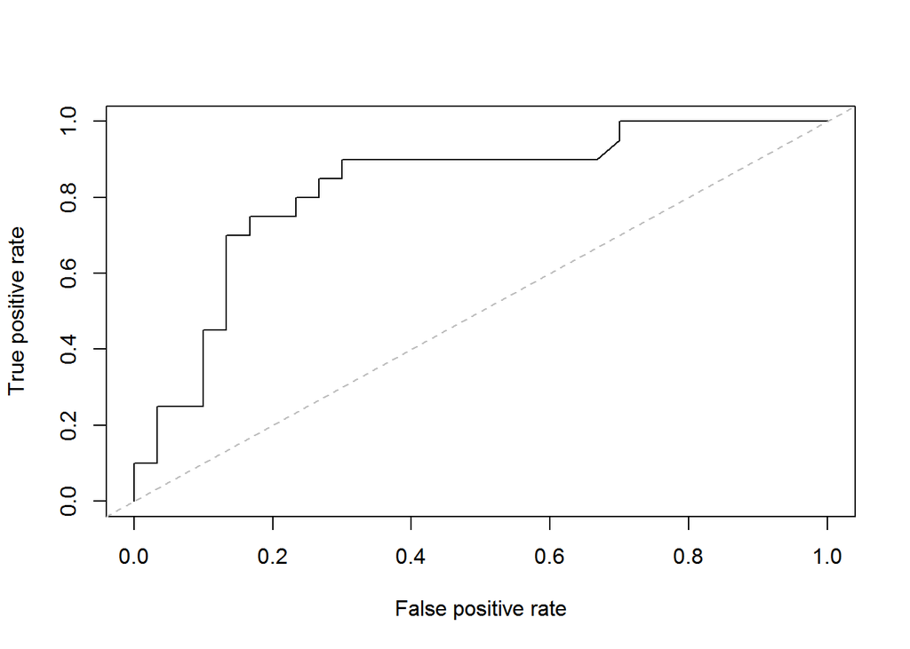

```r
m=prediction(pre,life$Y)
plot(performance(m,'tpr','fpr'))
abline(0,1, lty = 8, col = "grey")
```